# Nonlinear Models

## 4.1 Fitting a Logistic Regression using GAM

In order to fit a logistic regression GAM, we use the `I()` function in constructing the binary response variable, and set `family=binomial`.

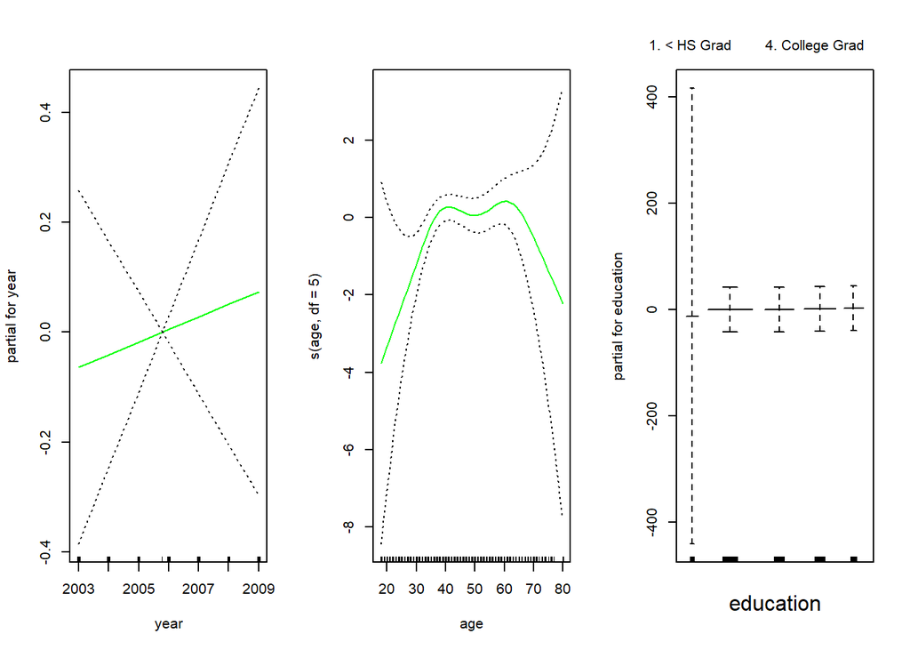

```r
gam.lr <- gam(I(wage > 250) ~ year + s(age, df = 5) + education, family = binomial, data = Wage)
par(mfrow = c(1, 3))
plot(gam.lr, se = T, col = "green")
```

Notice the large confidence band in the “<HS” category. This is because there are no high earners in the “<HS” category:

```r
table(Wage$education, I(Wage$wage > 250))
```

```
##
##                      FALSE TRUE
##   1. < HS Grad         268    0
##   2. HS Grad           966    5
##   3. Some College      643    7
##   4. College Grad      663   22
##   5. Advanced Degree   381   45
```

We fit a logistic regression GAM using all but this category. This provides more sensible results. Notice how we set the subset option below:

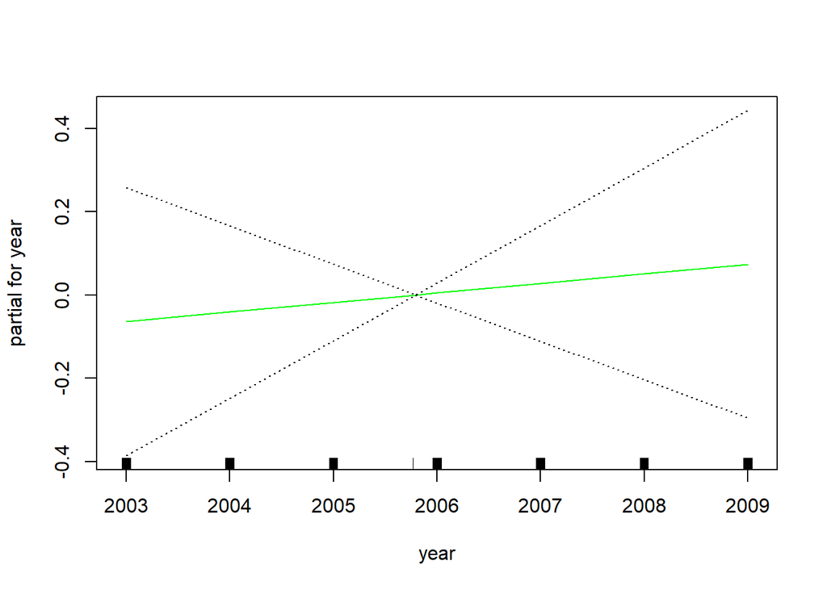

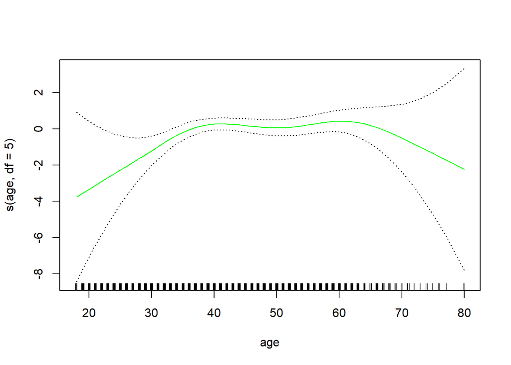

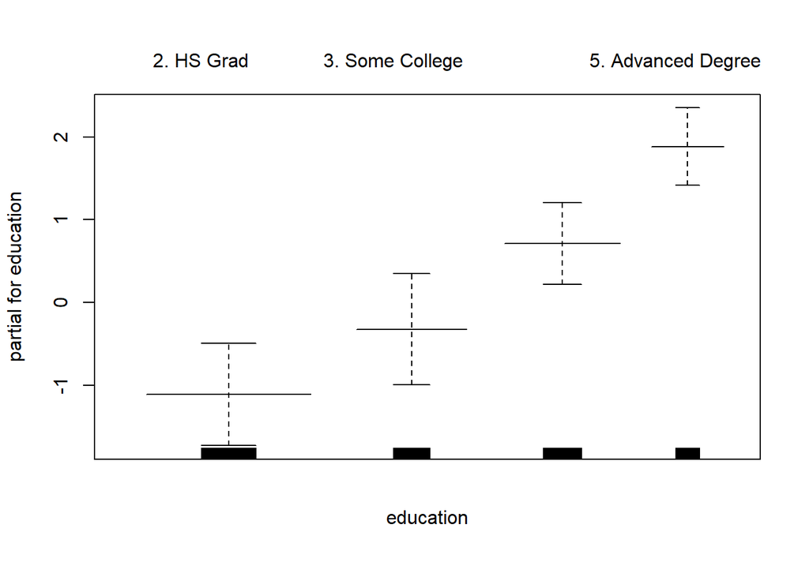

```r
gam.lr.s <- gam(I(wage > 250) ~ year + s(age, df = 5) + education, family = binomial, data = Wage, subset = (education != "1. < HS Grad"))
plot(gam.lr.s, se = T, col = "green")
```